Skip to contents

# Worked example: family CEOs and CEO pay

Source: [`vignettes/articles/ceo-pay.Rmd`](https://github.com/jespernwulff/bootmakr/blob/HEAD/vignettes/articles/ceo-pay.Rmd)

This article goes through a complete sensitivity analysis with `bootmakr`, from the first look at the standard errors to the check that the bootstrap can be trusted. It follows the four stages recommended by Lonati and Wulff (2026) and reproduces the empirical illustration of that paper. The reason a bootstrap is needed at all, that the ITCV and the analytic interval of `sensemakr` break down with robust standard errors, is shown in Why bootstrap?.

Every step is shown in R and in Stata. Pick a language on any tab and the rest of the page follows.

## The study

Chen, Chittoor, and Vissa (2021) ask whether CEOs who belong to the family that controls the firm are paid more than professional CEOs. In Model 2 of their Table 2 they regress the natural logarithm of total CEO pay on a family-CEO indicator and a set of controls: CEO tenure and education, firm sales, firm age, ownership shares, and year and industry indicators. The data cover 277 Indian firms observed over several years, 2,011 firm-year observations in all, and the standard errors are clustered by firm. The coefficient of the family-CEO indicator is 0.33 (*p* = .001): family CEOs earn roughly 39 percent more.

The authors themselves point out that the data are observational and that no natural experiment or instrument is available. CEO ability, family dynamics or firm strategy could drive both who becomes CEO and what the CEO is paid. The question for a sensitivity analysis is how strong such an omitted variable would have to be before the conclusion changes.

## Data and model

The authors share their data in an [OSF repository](https://osf.io/bsv2e/?view_only=885d1ed5498c4b3c8a1194882e468286), through the view-only link given with their article. The file can be read from there directly; the data are theirs, and this site keeps no copy.

**R**

```r
library(bootmakr)
library(haven)

osf  <- "https://osf.io/download/stk7y/?view_only=885d1ed5498c4b3c8a1194882e468286"
chen <- read_dta(osf)

ceo.model <- lg_ceopay ~ owner_ceo + ceo_tenure + PA_nic3_med + ceo_edu_dummy +
  lg_sales + firm_age + promoters_pct + institutions_pct +
  factor(year) + factor(nic_code_1digit)
```

`lg_ceopay` is the outcome, `owner_ceo` the family-CEO indicator, and `co_code` identifies the firm.

**Stata**

```stata
global osf "https://osf.io/download/stk7y/?view_only=885d1ed5498c4b3c8a1194882e468286"
copy "$osf" "ceo_pay.dta", replace
use "ceo_pay.dta", clear

global controls "ceo_tenure PA_nic3_med ceo_edu_dummy lg_sales firm_age"
global controls "$controls promoters_pct institutions_pct i.year i.nic_code_1digit"
```

`copy` downloads the file to the working directory. `lg_ceopay` is the outcome, `owner_ceo` the family-CEO indicator, and `co_code` identifies the firm. The global `$controls` holds the control variables and the year and industry indicators.

## Stages 1 and 2: which standard errors, and how different are they?

The first two stages ask whether robust standard errors are needed and, if so, how far they are from the conventional ones. Here the answer to the first question is yes. Family-CEO status varies mostly between firms, and observations of the same firm are not independent, which is why Chen et al. (2021) cluster by firm. For the second question, estimate the model both ways.

**R**

```r
library(sandwich)

fit <- lm(ceo.model, data = chen)

se <- c(conventional = sqrt(vcov(fit)["owner_ceo", "owner_ceo"]),
        clustered    = sqrt(vcovCL(fit, cluster = ~ co_code)["owner_ceo", "owner_ceo"]))

round(c(estimate = coef(fit)[["owner_ceo"]], se,
        ratio = se[["clustered"]] / se[["conventional"]]), 3)
```

```
#>     estimate conventional    clustered        ratio
#>        0.327        0.052        0.102        1.956
```

**Stata**

```stata
quietly regress lg_ceopay owner_ceo $controls
lincom owner_ceo

quietly regress lg_ceopay owner_ceo $controls, vce(cluster co_code)
lincom owner_ceo
```

```
 ( 1)  owner_ceo = 0

------------------------------------------------------------------------------
   lg_ceopay | Coefficient  Std. err.      t    P>|t|     [95% conf. interval]
-------------+----------------------------------------------------------------
         (1) |   .3269285   .0521019     6.27   0.000     .2247483    .4291086
------------------------------------------------------------------------------

 ( 1)  owner_ceo = 0

------------------------------------------------------------------------------
   lg_ceopay | Coefficient  Std. err.      t    P>|t|     [95% conf. interval]
-------------+----------------------------------------------------------------
         (1) |   .3269285   .1018931     3.21   0.001      .126342    .5275149
------------------------------------------------------------------------------
```

The coefficient is 0.33, as published. Its cluster-robust standard error (0.102) is almost twice the conventional one (0.052). With a gap of this size the impact threshold of a confounding variable (ITCV) can no longer be read as a product of correlations, because it is computed from a *t* statistic that now rests on a different variance estimator, and the analytic interval of `sensemakr` is off by the same factor. This is the situation `bootmakr` is made for; see Why bootstrap?.

## Stage 3: how strong is a plausible omitted variable?

An omitted variable is unobserved by definition, so its strength has to be judged against something that is observed. `sensemakr` (Cinelli & Hazlett, 2020) does this with a *benchmark*: an observed control variable whose explanatory power serves as the yardstick. The question becomes: what would the coefficient be if a variable `kd` times as strong as the benchmark had been left out? `bootmakr` computes that bias-adjusted coefficient and bootstraps the whole procedure, resampling firms, to obtain its standard error, confidence interval and *p*-value.

### An omitted variable as strong as CEO tenure

We take CEO tenure as the benchmark. The call needs the model, the treatment, the benchmark and the cluster variable, nothing more.

**R**

```r
ceo.sensitivity <- bootmakr(formula = ceo.model,
                            data = chen, treat = "owner_ceo",
                            benchmark_covariates = "ceo_tenure",
                            cluster = "co_code")
```

**Stata**

```stata
bootmakr lg_ceopay owner_ceo $controls, ///
    treat(owner_ceo) benchmark(ceo_tenure) cluster(co_code)
```

By default `bootmakr` evaluates an omitted variable exactly as strong as the benchmark (`kd = 1`) and draws 1,000 bootstrap samples. No seed is set unless you supply one, so two runs of this call give slightly different results. For the numbers reported in the paper we use 10,000 replications and a fixed seed.

**R**

```r
ceo.sensitivity <- bootmakr(formula = ceo.model,
                            data = chen, treat = "owner_ceo",
                            benchmark_covariates = "ceo_tenure",
                            cluster = "co_code",
                            reps = 10000, seed = 912323, progress = FALSE)
ceo.sensitivity
```

```
#>
#> Call:
#> bootmakr(formula = ceo.model, data = chen, treat = "owner_ceo",
#>     benchmark_covariates = "ceo_tenure", reps = 10000, seed = 912323,
#>     cluster = "co_code", progress = FALSE)
#>
#> Bootstrap sensitivity analysis (10,000 reps, n = 2,011, 277 clusters)
#> Benchmark: ceo_tenure | kd = 1, ky = 1
#>
#> Adjusted estimates (percentile 95% CI):
#>           Estimate Std. Err      2.5%    97.5% Pr(>|0|)
#> owner_ceo 0.254114 0.125204 -0.009662 0.483347    0.058 .
#> ---
#> Signif. codes:  0 '***' 0.001 '**' 0.01 '*' 0.05 '.' 0.1 ' ' 1
#> (H0: adjusted estimate = 0; CI and p-value from percentile bootstrap)
#>
#> Benchmark strength (descriptive: computed from the data, no standard errors involved)
#>                                Partial R2 |Partial r|
#> ceo_tenure with treatment | X      0.1447       0.380
#> ceo_tenure with outcome | D, X     0.0034       0.059
#> Implied strength of the omitted variable (sensemakr bounds):
#>                    kd   ky R2dz.x R2yz.dx Impact
#> 1.00x ceo_tenure 1.00 1.00 0.1691  0.0048  0.049
#> (R2dz.x, R2yz.dx: partial R2 of the omitted variable with the treatment given the
#>  covariates, and with the outcome given treatment and covariates. Impact: product of
#>  its partial correlations with the outcome and with the treatment, both given the
#>  covariates only, i.e. the scale of the ITCV; signed so that the omitted variable
#>  biases the estimate away from zero. Descriptive only: independent of the variance
#>  estimator, and not a threshold.)
```

(`progress = FALSE` only switches off the progress bar, which is useful on screen but not in a document.)

**Stata**

```stata
bootmakr lg_ceopay owner_ceo $controls, ///
    treat(owner_ceo) benchmark(ceo_tenure) cluster(co_code) ///
    reps(10000) seed(912323)
```

```
Bootstrap results                               Number of obs     =     2,011
                                                Replications      =    10,000

                 (Replications based on 277 clusters in co_code)
------------------------------------------------------------------------------
             |      Observed    Bootstrap                    Percentile
             |       Coef.      Std. Err.    P-value    [95% Conf. Interval]
-------------+----------------------------------------------------------------
owner_ceo    |     .254114      .1278125      0.0600    -.0110033    .4866132
------------------------------------------------------------------------------
Note: CI is percentile bootstrap confidence interval
      P-value is bootstrap p-value (H0: owner_ceo = 0)
      Benchmark: ceo_tenure, kd = 1, ky = 1

Benchmark strength (descriptive; no standard errors involved)
------------------------------------------------------------------------------
Benchmark: ceo_tenure
                                                 Partial R2    |Partial corr.|
  with owner_ceo | X                                 0.1447             0.380
  with lg_ceopay | owner_ceo, X                      0.0034             0.059
------------------------------------------------------------------------------
Implied strength of the omitted variable (sensemakr bounds):
     kd      ky      R2dz.x     R2yz.dx     Impact
   1.00    1.00       0.1691     0.0048      0.049
------------------------------------------------------------------------------
Note: R2dz.x (R2yz.dx) = partial R2 of the omitted variable with the
      treatment given the covariates (with the outcome given treatment
      and covariates). Impact = product of its partial correlations with
      the outcome and with the treatment, both given the covariates only:
      the scale of the ITCV; signed so that the omitted variable biases
      the estimate away from zero. Descriptive only: independent of the
      variance estimator, and not a threshold.
```

The first table holds the answer. Had a variable as strong as CEO tenure been omitted, the coefficient of family CEO would be 0.25 instead of 0.33. That point estimate is the one `sensemakr` reports, and it is the same in R and Stata. What `bootmakr` adds is the inference: a bootstrap standard error of 0.13, a percentile 95 percent confidence interval from −0.01 to 0.49, and a bootstrap *p*-value of .06 in Stata (.06 in R, with an interval from −0.01 to 0.48). The two programs draw different random numbers, so their bootstrap results agree up to simulation error. The published effect would therefore no longer be statistically significant at the 5 percent level if an omitted variable as strong as CEO tenure were at work.

The second block says what “as strong as CEO tenure” means. CEO tenure explains 14.5 percent of the variance of family-CEO status that the other covariates leave unexplained (a partial correlation of .38), and 0.3 percent of the remaining variance of log CEO pay (a partial correlation of .06). The omitted variable assumed at `kd = 1` has an impact of .05: the product of its partial correlations with CEO pay and with family-CEO status, on the scale on which the ITCV is stated. These are descriptive statistics of the data. No standard error enters them, so they do not depend on whether the model is estimated with conventional or clustered standard errors, and they are the same in every bootstrap run. The article How strong is the benchmark? explains the block in detail.

### An omitted variable half as strong

Is the conclusion equally fragile for a weaker omitted variable? Set `kd` to 0.5.

**R**

```r
half <- bootmakr(ceo.model, data = chen, treat = "owner_ceo",
                 benchmark_covariates = "ceo_tenure", kd = 0.5,
                 cluster = "co_code",
                 reps = 10000, seed = 912323, progress = FALSE)
half
```

```
#>
#> Call:
#> bootmakr(formula = ceo.model, data = chen, treat = "owner_ceo",
#>     benchmark_covariates = "ceo_tenure", kd = 0.5, reps = 10000,
#>     seed = 912323, cluster = "co_code", progress = FALSE)
#>
#> Bootstrap sensitivity analysis (10,000 reps, n = 2,011, 277 clusters)
#> Benchmark: ceo_tenure | kd = 0.5, ky = 0.5
#>
#> Adjusted estimates (percentile 95% CI):
#>           Estimate Std. Err     2.5%    97.5% Pr(>|0|)
#> owner_ceo 0.292713 0.110681 0.073551 0.506855    0.008 **
#> ---
#> Signif. codes:  0 '***' 0.001 '**' 0.01 '*' 0.05 '.' 0.1 ' ' 1
#> (H0: adjusted estimate = 0; CI and p-value from percentile bootstrap)
#>
#> Benchmark strength (descriptive: computed from the data, no standard errors involved)
#>                                Partial R2 |Partial r|
#> ceo_tenure with treatment | X      0.1447       0.380
#> ceo_tenure with outcome | D, X     0.0034       0.059
#> Implied strength of the omitted variable (sensemakr bounds):
#>                    kd   ky R2dz.x R2yz.dx Impact
#> 0.50x ceo_tenure 0.50 0.50 0.0846  0.0024  0.025
#> (R2dz.x, R2yz.dx: partial R2 of the omitted variable with the treatment given the
#>  covariates, and with the outcome given treatment and covariates. Impact: product of
#>  its partial correlations with the outcome and with the treatment, both given the
#>  covariates only, i.e. the scale of the ITCV; signed so that the omitted variable
#>  biases the estimate away from zero. Descriptive only: independent of the variance
#>  estimator, and not a threshold.)
```

**Stata**

```stata
bootmakr lg_ceopay owner_ceo $controls, ///
    treat(owner_ceo) benchmark(ceo_tenure) kd(0.5) cluster(co_code) ///
    reps(10000) seed(912323)
```

```
Bootstrap results                               Number of obs     =     2,011
                                                Replications      =    10,000

                 (Replications based on 277 clusters in co_code)
------------------------------------------------------------------------------
             |      Observed    Bootstrap                    Percentile
             |       Coef.      Std. Err.    P-value    [95% Conf. Interval]
-------------+----------------------------------------------------------------
owner_ceo    |    .2927133      .1121849      0.0100     .0723644    .5121048
------------------------------------------------------------------------------
Note: CI is percentile bootstrap confidence interval
      P-value is bootstrap p-value (H0: owner_ceo = 0)
      Benchmark: ceo_tenure, kd = .5, ky = .5

Benchmark strength (descriptive; no standard errors involved)
------------------------------------------------------------------------------
Benchmark: ceo_tenure
                                                 Partial R2    |Partial corr.|
  with owner_ceo | X                                 0.1447             0.380
  with lg_ceopay | owner_ceo, X                      0.0034             0.059
------------------------------------------------------------------------------
Implied strength of the omitted variable (sensemakr bounds):
     kd      ky      R2dz.x     R2yz.dx     Impact
   0.50    0.50       0.0846     0.0024      0.025
------------------------------------------------------------------------------
Note: R2dz.x (R2yz.dx) = partial R2 of the omitted variable with the
      treatment given the covariates (with the outcome given treatment
      and covariates). Impact = product of its partial correlations with
      the outcome and with the treatment, both given the covariates only:
      the scale of the ITCV; signed so that the omitted variable biases
      the estimate away from zero. Descriptive only: independent of the
      variance estimator, and not a threshold.
```

An omitted variable half as strong as CEO tenure leaves the conclusion intact: the adjusted coefficient is 0.29, with a confidence interval from 0.07 to 0.51 and *p* = .01 in Stata (0.07 to 0.51 and *p* = .008 in R). The finding of Chen et al. (2021) withstands moderate omitted-variable bias, but not an omitted variable as strong as CEO tenure itself.

### The breakdown point

Instead of trying one strength at a time, give `kd` a range of values. `bootmakr` then reports one row per value, and the plot shows where the adjusted estimate stops being statistically significant: the *breakdown point*. With CEO tenure the result already breaks down between `kd = 0.5` and `kd = 1`, which leaves little to plot, so we take a weaker benchmark, firm age, and let `kd` run from 0.5 to 4.

**R**

```r
breakdown <- bootmakr(ceo.model, data = chen, treat = "owner_ceo",
                      benchmark_covariates = "firm_age",
                      kd = seq(0.5, 4, by = 0.5),
                      cluster = "co_code",
                      reps = 10000, seed = 912323, progress = FALSE)
breakdown
```

```
#>
#> Call:
#> bootmakr(formula = ceo.model, data = chen, treat = "owner_ceo",
#>     benchmark_covariates = "firm_age", kd = seq(0.5, 4, by = 0.5),
#>     reps = 10000, seed = 912323, cluster = "co_code", progress = FALSE)
#>
#> Bootstrap sensitivity analysis (10,000 reps, n = 2,011, 277 clusters)
#> Benchmark: firm_age | kd = 0.5 1 1.5 2 2.5 3 3.5 4, ky = 0.5 1 1.5 2 2.5 3 3.5 4
#>
#> Adjusted estimates (percentile 95% CI):
#>                    Estimate Std. Err      2.5%    97.5% Pr(>|0|)
#> owner_ceo (kd=0.5) 0.315192 0.104763  0.109778 0.519883   0.0024 **
#> owner_ceo (kd=1)   0.303186 0.106338  0.091252 0.505322   0.0052 **
#> owner_ceo (kd=1.5) 0.290898 0.109926  0.065782 0.494361   0.0126  *
#> owner_ceo (kd=2)   0.278311 0.115755  0.032734 0.485281   0.0272  *
#> owner_ceo (kd=2.5) 0.265410 0.124054 -0.007883 0.477372   0.0564  .
#> owner_ceo (kd=3)   0.252178 0.135130 -0.058145 0.472694   0.0942  .
#> owner_ceo (kd=3.5) 0.238594 0.149549 -0.115839 0.465659    0.154
#> owner_ceo (kd=4)   0.224639 0.169238 -0.182410 0.459321    0.213
#> ---
#> Signif. codes:  0 '***' 0.001 '**' 0.01 '*' 0.05 '.' 0.1 ' ' 1
#> (H0: adjusted estimate = 0; CI and p-value from percentile bootstrap)
#>
#> Benchmark strength (descriptive: computed from the data, no standard errors involved)
#>                              Partial R2 |Partial r|
#> firm_age with treatment | X      0.0394       0.198
#> firm_age with outcome | D, X     0.0023       0.047
#> Implied strength of the omitted variable (sensemakr bounds):
#>                  kd   ky R2dz.x R2yz.dx Impact
#> 0.50x firm_age 0.50 0.50 0.0205  0.0012  0.008
#> 1.00x firm_age 1.00 1.00 0.0410  0.0024  0.015
#> 1.50x firm_age 1.50 1.50 0.0615  0.0037  0.023
#> 2.00x firm_age 2.00 2.00 0.0820  0.0049  0.030
#> 2.50x firm_age 2.50 2.50 0.1025  0.0062  0.038
#> 3.00x firm_age 3.00 3.00 0.1229  0.0074  0.045
#> 3.50x firm_age 3.50 3.50 0.1434  0.0087  0.052
#> 4.00x firm_age 4.00 4.00 0.1639  0.0099  0.059
#> (R2dz.x, R2yz.dx: partial R2 of the omitted variable with the treatment given the
#>  covariates, and with the outcome given treatment and covariates. Impact: product of
#>  its partial correlations with the outcome and with the treatment, both given the
#>  covariates only, i.e. the scale of the ITCV; signed so that the omitted variable
#>  biases the estimate away from zero. Descriptive only: independent of the variance
#>  estimator, and not a threshold.)
```

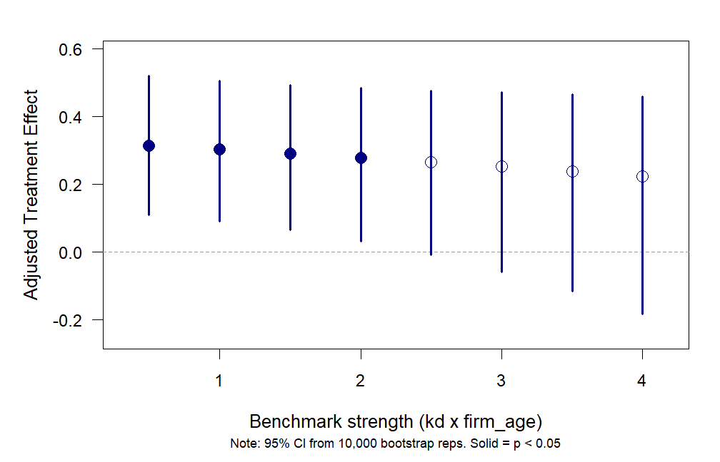

Bias-adjusted effect of family CEO with bootstrap 95 percent confidence intervals, for an omitted variable 0.5 to 4 times as strong as firm age (R).

```r
plot(breakdown, type = "kd_sweep")
```

**Stata**

The `plot` option draws the figure.

```stata
bootmakr lg_ceopay owner_ceo $controls, ///
    treat(owner_ceo) benchmark(firm_age) kd(0.5 1 1.5 2 2.5 3 3.5 4) ///
    cluster(co_code) reps(10000) seed(912323) plot
```

```
Bootstrap results                                Number of obs     =     2,011
                                                 Replications      =    10,000

                  (Replications based on 277 clusters in co_code)
-------------------------------------------------------------------------------
              |      Observed    Bootstrap                    Percentile
              |       Coef.      Std. Err.    P-value    [95% Conf. Interval]
--------------+----------------------------------------------------------------
owner_ceo_.5  |    .3151919      .1050923      0.0024     .1140096    .5223852
owner_ceo_1   |    .3031863      .1064594      0.0036     .0952439    .5105461
owner_ceo_1.5 |    .2908978      .1098538      0.0110     .0709601    .5001372
owner_ceo_2   |    .2783112      .1155137      0.0232     .0396458    .4916347
owner_ceo_2.5 |    .2654103      .1236761      0.0504    -.0008235    .4830732
owner_ceo_3   |    .2521776      .1346452      0.0902    -.0529467    .4762372
owner_ceo_3.5 |     .238594      .1489642      0.1488     -.117015    .4705466
owner_ceo_4   |    .2246388      .1680864      0.2084    -.1872034    .4652436
-------------------------------------------------------------------------------
Note: CI is percentile bootstrap confidence interval
      P-value is bootstrap p-value (H0: owner_ceo = 0)
      Benchmark: firm_age, kd = .5 1 1.5 2 2.5 3 3.5 4, ky = .5 1 1.5 2 2.5 3 3.5 4

Benchmark strength (descriptive; no standard errors involved)
------------------------------------------------------------------------------
Benchmark: firm_age
                                                 Partial R2    |Partial corr.|
  with owner_ceo | X                                 0.0394             0.198
  with lg_ceopay | owner_ceo, X                      0.0023             0.047
------------------------------------------------------------------------------
Implied strength of the omitted variable (sensemakr bounds):
     kd      ky      R2dz.x     R2yz.dx     Impact
   0.50    0.50       0.0205     0.0012      0.008
   1.00    1.00       0.0410     0.0024      0.015
   1.50    1.50       0.0615     0.0037      0.023
   2.00    2.00       0.0820     0.0049      0.030
   2.50    2.50       0.1025     0.0062      0.038
   3.00    3.00       0.1229     0.0074      0.045
   3.50    3.50       0.1434     0.0087      0.052
   4.00    4.00       0.1639     0.0099      0.059
------------------------------------------------------------------------------
Note: R2dz.x (R2yz.dx) = partial R2 of the omitted variable with the
      treatment given the covariates (with the outcome given treatment
      and covariates). Impact = product of its partial correlations with
      the outcome and with the treatment, both given the covariates only:
      the scale of the ITCV; signed so that the omitted variable biases
      the estimate away from zero. Descriptive only: independent of the
      variance estimator, and not a threshold.
```

[figure not shown]

Bias-adjusted effect of family CEO with bootstrap 95 percent confidence intervals, for an omitted variable 0.5 to 4 times as strong as firm age (Stata).

Solid markers are significant at the 5 percent level, hollow markers are not. The adjusted estimate declines only gently, from 0.32 to 0.22, while its confidence interval widens. The breakdown point is at about 2.5: an omitted variable would have to be roughly two and a half times as strong as firm age to make the effect statistically insignificant (*p* = .050 in Stata and .056 in R at `kd = 2.5`). In terms of the benchmark-strength block, that is a variable with a partial R<sup>2</sup> of about .10 with family-CEO status and .006 with CEO pay, an impact of .04 on the ITCV scale.

### A group of covariates as benchmark

The benchmark can also be a group of covariates taken together, here CEO tenure and CEO education. Because the two are jointly stronger than either one alone, smaller multiples are of interest.

**R**

```r
grouped <- bootmakr(ceo.model, data = chen, treat = "owner_ceo",
                    gbenchmark_covariates = c("ceo_tenure", "ceo_edu_dummy"),
                    kd = seq(0.1, 0.5, by = 0.1),
                    cluster = "co_code",
                    reps = 10000, seed = 912323, progress = FALSE)
grouped
```

```
#>
#> Call:
#> bootmakr(formula = ceo.model, data = chen, treat = "owner_ceo",
#>     gbenchmark_covariates = c("ceo_tenure", "ceo_edu_dummy"),
#>     kd = seq(0.1, 0.5, by = 0.1), reps = 10000, seed = 912323,
#>     cluster = "co_code", progress = FALSE)
#>
#> Bootstrap sensitivity analysis (10,000 reps, n = 2,011, 277 clusters)
#> Benchmark: ceo_tenure, ceo_edu_dummy | kd = 0.1 0.2 0.3 0.4 0.5, ky = 0.1 0.2 0.3 0.4 0.5
#>
#> Adjusted estimates (percentile 95% CI):
#>                    Estimate Std. Err      2.5%    97.5% Pr(>|0|)
#> owner_ceo (kd=0.1) 0.307507 0.106758  0.098692 0.515751    0.004 **
#> owner_ceo (kd=0.2) 0.287655 0.109410  0.068888 0.499150   0.0104  *
#> owner_ceo (kd=0.3) 0.267353 0.112958  0.038996 0.483207   0.0246  *
#> owner_ceo (kd=0.4) 0.246580 0.117447  0.004183 0.466800   0.0464  *
#> owner_ceo (kd=0.5) 0.225312 0.122917 -0.036348 0.450088    0.081  .
#> ---
#> Signif. codes:  0 '***' 0.001 '**' 0.01 '*' 0.05 '.' 0.1 ' ' 1
#> (H0: adjusted estimate = 0; CI and p-value from percentile bootstrap)
#>
#> Benchmark strength (descriptive: computed from the data, no standard errors involved)
#>                                                Partial R2 |Partial r|
#> ceo_tenure + ceo_edu_dummy with treatment | X      0.1450       0.381
#> ceo_tenure + ceo_edu_dummy with outcome | D, X     0.0293       0.171
#> Implied strength of the omitted variable (sensemakr bounds):
#>                                    kd   ky R2dz.x R2yz.dx Impact
#> 0.10x ceo_tenure + ceo_edu_dummy 0.10 0.10 0.0170  0.0041  0.011
#> 0.20x ceo_tenure + ceo_edu_dummy 0.20 0.20 0.0339  0.0082  0.021
#> 0.30x ceo_tenure + ceo_edu_dummy 0.30 0.30 0.0509  0.0123  0.031
#> 0.40x ceo_tenure + ceo_edu_dummy 0.40 0.40 0.0679  0.0165  0.041
#> 0.50x ceo_tenure + ceo_edu_dummy 0.50 0.50 0.0848  0.0207  0.052
#> (R2dz.x, R2yz.dx: partial R2 of the omitted variable with the treatment given the
#>  covariates, and with the outcome given treatment and covariates. Impact: product of
#>  its partial correlations with the outcome and with the treatment, both given the
#>  covariates only, i.e. the scale of the ITCV; signed so that the omitted variable
#>  biases the estimate away from zero. Descriptive only: independent of the variance
#>  estimator, and not a threshold.)
```

**Stata**

```stata
bootmakr lg_ceopay owner_ceo $controls, ///
    treat(owner_ceo) gbenchmark(ceo_tenure ceo_edu_dummy) kd(0.1 0.2 0.3 0.4 0.5) ///
    cluster(co_code) reps(10000) seed(912323) plot
```

```
Bootstrap results                               Number of obs     =     2,011
                                                Replications      =    10,000

                 (Replications based on 277 clusters in co_code)
------------------------------------------------------------------------------
             |      Observed    Bootstrap                    Percentile
             |       Coef.      Std. Err.    P-value    [95% Conf. Interval]
-------------+----------------------------------------------------------------
owner_ceo_.1 |    .3075068      .1074965      0.0022     .1001084    .5199273
owner_ceo_.2 |    .2876552      .1103445      0.0084     .0699102    .5012977
owner_ceo_.3 |    .2673534      .1140841      0.0214     .0406476     .485481
owner_ceo_.4 |    .2465799      .1187558      0.0436     .0074298    .4701601
owner_ceo_.5 |    .2253117      .1243957      0.0868    -.0313949    .4559408
------------------------------------------------------------------------------
Note: CI is percentile bootstrap confidence interval
      P-value is bootstrap p-value (H0: owner_ceo = 0)
      Benchmark: ceo_tenure ceo_edu_dummy, kd = .1 .2 .3 .4 .5, ky = .1 .2 .3 .4 .5

Benchmark strength (descriptive; no standard errors involved)
------------------------------------------------------------------------------
Benchmark: ceo_tenure+ceo_edu_dummy
                                                 Partial R2    |Partial corr.|
  with owner_ceo | X                                 0.1450             0.381
  with lg_ceopay | owner_ceo, X                      0.0293             0.171
------------------------------------------------------------------------------
Implied strength of the omitted variable (sensemakr bounds):
     kd      ky      R2dz.x     R2yz.dx     Impact
   0.10    0.10       0.0170     0.0041      0.011
   0.20    0.20       0.0339     0.0082      0.021
   0.30    0.30       0.0509     0.0123      0.031
   0.40    0.40       0.0679     0.0165      0.041
   0.50    0.50       0.0848     0.0207      0.052
------------------------------------------------------------------------------
Note: R2dz.x (R2yz.dx) = partial R2 of the omitted variable with the
      treatment given the covariates (with the outcome given treatment
      and covariates). Impact = product of its partial correlations with
      the outcome and with the treatment, both given the covariates only:
      the scale of the ITCV; signed so that the omitted variable biases
      the estimate away from zero. Descriptive only: independent of the
      variance estimator, and not a threshold.
```

Together, CEO tenure and CEO education explain 14.5 percent of the remaining variance of family-CEO status and 2.9 percent of that of CEO pay. Against this stronger yardstick the effect remains statistically significant for an omitted variable up to 0.4 times as strong as the two together and no longer at 0.5 times (*p* = .087 in Stata, .081 in R).

## Stage 4: can the bootstrap be trusted?

A bootstrap result is only as good as the bootstrap behind it. Three checks are worth making.

**Enough clusters.** The cluster bootstrap resamples firms, and it needs enough of them. Here there are 277, with up to ten observations each, which the simulations in Lonati and Wulff (2026) suggest is sufficient.

**No failed replications.** Some bootstrap samples can make the assumed omitted variable impossible, in the sense that it would have to explain more variance than is left. Such replications fail and are dropped, and `bootmakr` says so below the table. There is no such note in any of the runs above. A handful of failures is harmless; many of them mean that the assumed strength is close to the limit of what the data allow.

**Enough replications.** The headline result sits close to the 5 percent threshold, so the number of replications matters. Run the default call (1,000 replications) with four different seeds:

**R**

```r
seeds <- c(101, 202, 303, 404)

runs <- lapply(seeds, function(s) {
  bootmakr(ceo.model, data = chen, treat = "owner_ceo",
           benchmark_covariates = "ceo_tenure", cluster = "co_code",
           seed = s, progress = FALSE)$results
})

cbind(seed = seeds, do.call(rbind, runs)[, c("pvalue", "ci_lower", "ci_upper")])
```

```
#>   seed pvalue      ci_lower  ci_upper
#> 1  101  0.052 -0.0004368531 0.4802692
#> 2  202  0.056 -0.0041221694 0.4793521
#> 3  303  0.058 -0.0053770558 0.4874632
#> 4  404  0.058 -0.0057290584 0.4843642
```

**Stata**

```stata
foreach s in 101 202 303 404 {
    quietly bootmakr lg_ceopay owner_ceo $controls, ///
        treat(owner_ceo) benchmark(ceo_tenure) cluster(co_code) seed(`s')
    display "seed `s':  p = " %5.3f r(p) "   95% CI [" %6.3f r(ci_lower) ", " %5.3f r(ci_upper) "]"
}
```

```
seed 101:  p = 0.046   95% CI [ 0.002, 0.474]
seed 202:  p = 0.060   95% CI [-0.017, 0.500]
seed 303:  p = 0.058   95% CI [-0.008, 0.469]
seed 404:  p = 0.058   95% CI [-0.011, 0.485]
```

With 1,000 replications the *p*-value changes from seed to seed: between .052 and .058 in these R runs, and between .046 and .060 in the Stata runs. The differences are small, but the eight values lie on both sides of .05, so the verdict would depend on the seed. The `converge` option shows how many replications it takes for the result to settle. It runs the bootstrap once, here with 40,000 replications, and recomputes the standard error and the *p*-value on the first 1,000, 2,000, … replications.

**R**

```r
check <- bootmakr(ceo.model, data = chen, treat = "owner_ceo",
                  benchmark_covariates = "ceo_tenure", cluster = "co_code",
                  reps = 40000, seed = 912323, progress = FALSE,
                  converge = list(minreps = 1000, stepsize = 1000,
                                  threshold = 10000))
check
```

```
#>
#> Call:
#> bootmakr(formula = ceo.model, data = chen, treat = "owner_ceo",
#>     benchmark_covariates = "ceo_tenure", reps = 40000, seed = 912323,
#>     cluster = "co_code", progress = FALSE, converge = list(minreps = 1000,
#>         stepsize = 1000, threshold = 10000))
#>
#> Bootstrap sensitivity analysis (40,000 reps, n = 2,011, 277 clusters)
#> Benchmark: ceo_tenure | kd = 1, ky = 1
#>
#> Adjusted estimates (percentile 95% CI):
#>           Estimate Std. Err      2.5%    97.5% Pr(>|0|)
#> owner_ceo 0.254114 0.127376 -0.015484 0.485627   0.0633 .
#> ---
#> Signif. codes:  0 '***' 0.001 '**' 0.01 '*' 0.05 '.' 0.1 ' ' 1
#> (H0: adjusted estimate = 0; CI and p-value from percentile bootstrap)
#>
#> Benchmark strength (descriptive: computed from the data, no standard errors involved)
#>                                Partial R2 |Partial r|
#> ceo_tenure with treatment | X      0.1447       0.380
#> ceo_tenure with outcome | D, X     0.0034       0.059
#> Implied strength of the omitted variable (sensemakr bounds):
#>                    kd   ky R2dz.x R2yz.dx Impact
#> 1.00x ceo_tenure 1.00 1.00 0.1691  0.0048  0.049
#> (R2dz.x, R2yz.dx: partial R2 of the omitted variable with the treatment given the
#>  covariates, and with the outcome given treatment and covariates. Impact: product of
#>  its partial correlations with the outcome and with the treatment, both given the
#>  covariates only, i.e. the scale of the ITCV; signed so that the omitted variable
#>  biases the estimate away from zero. Descriptive only: independent of the variance
#>  estimator, and not a threshold.)
#>
#> Convergence diagnostics (reps 1000 to 40000 by 1000, threshold = 10000):
#>              Mean  Range CV % Range (>=10000) CV% (>=10000)
#> Std. error 0.1270 0.0036 0.85          0.0029          0.62
#> P-value    0.0618 0.0150 4.94          0.0070          3.11
#> (CV % = coefficient of variation: sd / mean * 100)
```

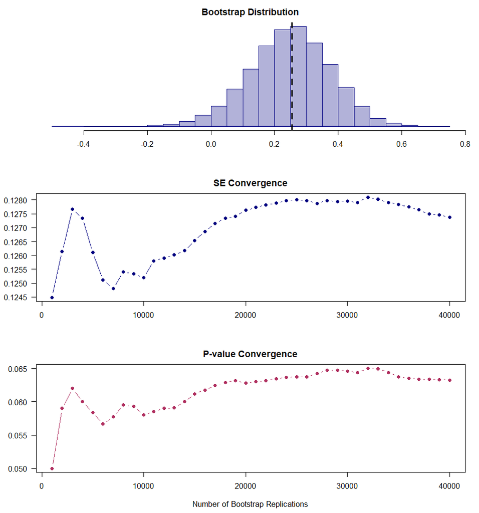

Bootstrap distribution of the adjusted estimate (top), and its standard error (middle) and p-value (bottom) as the number of replications grows (R).

```r
plot(check, type = "convergence")
```

**Stata**

```stata
bootmakr lg_ceopay owner_ceo $controls, ///
    treat(owner_ceo) benchmark(ceo_tenure) cluster(co_code) ///
    reps(40000) seed(912323) ///
    converge(minreps(1000) stepsize(1000) threshold(10000))
```

```
Bootstrap results                               Number of obs     =     2,011
                                                Replications      =    40,000

                 (Replications based on 277 clusters in co_code)
------------------------------------------------------------------------------
             |      Observed    Bootstrap                    Percentile
             |       Coef.      Std. Err.    P-value    [95% Conf. Interval]
-------------+----------------------------------------------------------------
owner_ceo    |     .254114      .1278329      0.0624    -.0141857    .4874146
------------------------------------------------------------------------------
Note: CI is percentile bootstrap confidence interval
      P-value is bootstrap p-value (H0: owner_ceo = 0)
      Benchmark: ceo_tenure, kd = 1, ky = 1

Benchmark strength (descriptive; no standard errors involved)
------------------------------------------------------------------------------
Benchmark: ceo_tenure
                                                 Partial R2    |Partial corr.|
  with owner_ceo | X                                 0.1447             0.380
  with lg_ceopay | owner_ceo, X                      0.0034             0.059
------------------------------------------------------------------------------
Implied strength of the omitted variable (sensemakr bounds):
     kd      ky      R2dz.x     R2yz.dx     Impact
   1.00    1.00       0.1691     0.0048      0.049
------------------------------------------------------------------------------
Note: R2dz.x (R2yz.dx) = partial R2 of the omitted variable with the
      treatment given the covariates (with the outcome given treatment
      and covariates). Impact = product of its partial correlations with
      the outcome and with the treatment, both given the covariates only:
      the scale of the ITCV; signed so that the omitted variable biases
      the estimate away from zero. Descriptive only: independent of the
      variance estimator, and not a threshold.

Computing convergence statistics........................................
------------------------------------------------------------------------------
Bootstrap convergence diagnostics
Reps: 1000(1000)40000
------------------------------------------------------------------------------
Summary across replication counts
              |    Mean      Range       CV%       Range       CV%
              |    (all)     (all)      (all)     (>=10000)  (>=10000)
--------------+---------------------------------------------------------------
Std. error    |    0.1282    0.0047      0.57      0.0008      0.14
P-value       |    0.0620    0.0100      2.64      0.0036      1.50
------------------------------------------------------------------------------
Note: CV% = Coefficient of variation (standard deviation / mean x 100)
      (all) = statistics across all replication counts
      (>=10000) = statistics for replication counts >= 10000
```

[figure not shown]

Bootstrap distribution of the adjusted estimate (top), and its standard error (middle) and p-value (bottom) as the number of replications grows (Stata).

## What to report

A report of this analysis would state

- the benchmark and why it was chosen (here CEO tenure, a substantively meaningful covariate that is closely tied to who becomes a family CEO), and its strength in partial R<sup>2</sup> terms;
- the multiples `kd` examined, and for each the bias-adjusted coefficient with its bootstrap confidence interval and *p*-value;
- how the bootstrap was run: the resampling unit (firms), the number of replications, the seed, and the number of failed replications;
- the outcome of the convergence check if the verdict is close to the significance threshold.

For example: *Assuming an omitted variable as strong as CEO tenure, the bias-adjusted effect of family CEO on log CEO pay is 0.25 (cluster bootstrap with 10,000 replications; percentile 95% CI [−0.01, 0.49], p = .06).*

A sensitivity analysis does not replace a research design that rules out omitted variables. It makes explicit how much unobserved confounding a conclusion can take, and it leaves the judgment of whether that much is plausible to the reader.

## Notes on reproducibility

The R results on this page were produced with R 4.2.1, `bootmakr` 0.4.0 and `sensemakr` 0.1.5; the Stata results with StataNow 19.5, `bootmakr` 1.2.0 and the `sensemakr` command from SSC. With the seed shown, each program reproduces its own numbers exactly. On an ordinary laptop, 1,000 replications of this model take about 20 seconds in R and 45 seconds in Stata, and 10,000 replications under 4 and 8 minutes.

## References

Chen, G., Chittoor, R., & Vissa, B. (2021). Does nepotism run in the family? CEO pay and pay-performance sensitivity in Indian family firms. *Strategic Management Journal*, 42(7), 1326–1343. https://doi.org/10.1002/smj.3263

Cinelli, C., & Hazlett, C. (2020). Making sense of sensitivity: Extending omitted variable bias. *Journal of the Royal Statistical Society: Series B*, 82(1), 39–67. https://doi.org/10.1111/rssb.12348

Cinelli, C., Ferwerda, J., & Hazlett, C. (2024). sensemakr: Sensitivity analysis tools for OLS in R and Stata. *Observational Studies*, 10(2), 93–127. https://doi.org/10.1353/obs.2024.a946583

Lonati, S., & Wulff, J. N. (2026). Why you should not use the ITCV with robust standard errors (and what to do instead). *Academy of Management Proceedings*, 2026(1). https://doi.org/10.5465/AMPROC.2026.247bp